# AS03_join_edu_data

龔泓愷

10/10/2019

```r
library(tidyverse)
options(stringsAsFactors = F)
```

# Q1 Joining educational data

- Reading educational data from the following csv file.

## Town level educational data

- Original data is village-level data
- Following In-Class tutorial, using `group_by()` to create town-level statistical data.

```r
edu_town <- read_csv("data/opendata107Y020.csv") %>%
  slice(-1) %>% # 移除中文標題
  mutate_at(vars(contains("edu")), funs(as.numeric(.))) %>% # 把 char 轉 num
  mutate(site_id = str_replace(site_id, "鳳山一", "鳳山區")) %>%
  mutate(site_id = str_replace(site_id, "鳳山二", "鳳山區")) %>%
  mutate(site_id = str_replace(site_id, "三民一", "三民區")) %>%
  mutate(site_id = str_replace(site_id, "三民二", "三民區")) %>%
  mutate(site_id = str_replace(site_id, "　", "")) %>% # "北 區" > "北區"
  group_by(site_id) %>%
  summarise_at(vars(contains("edu")), funs(sum)) %>% # 含有 edu 的欄位分別依 group 加總
  glimpse()
```

```
## Observations: 368
## Variables: 48
## $ site_id                                     <chr> "宜蘭縣三星鄉", "宜蘭縣大同鄉"...
## $ edu_age_15up_total                          <dbl> 19678, 5161, 36047...
## $ edu_doctor_graduated_m                      <dbl> 30, 1, 51, 58, 25,...
## $ edu_doctor_graduated_f                      <dbl> 13, 2, 19, 19, 5, ...
## $ edu_doctor_ungraduated_m                    <dbl> 15, 0, 49, 48, 15,...
## $ edu_doctor_ungraduated_f                    <dbl> 13, 0, 12, 14, 9, ...
## $ edu_master_graduated_m                      <dbl> 333, 23, 803, 1042...
## $ edu_master_graduated_f                      <dbl> 179, 9, 426, 565, ...
## $ edu_master_ungraduated_m                    <dbl> 88, 19, 253, 336, ...
## $ edu_master_ungraduated_f                    <dbl> 70, 17, 185, 237, ...
## $ edu_university_graduated_m                  <dbl> 1361, 174, 3009, 3...
## $ edu_university_graduated_f                  <dbl> 1332, 164, 3010, 4...
## $ edu_university_ungraduated_m                <dbl> 511, 111, 1066, 14...
```

[output cut: 35 more lines]

```r
#edu_town_long <- edu_town %>%
#  gather(key = "key", "value", -site_id) %>%
#  mutate(key = str_replace(key, "illiterate", "illiterate_illiterate")) %>%
#  mutate(key = str_replace(key, "selftaughtl", "selftaught_selftaught")) %>%
#  mutate(key = str_replace(key, "juniorcollege_2ys", "juniorcollege2ys")) %>%
#  mutate(key = str_replace(key, "juniorcollege_5ys_final2y", "juniorcollege5ysfinal2y"))  %>%
#  mutate(key = str_replace(key, "juniorcollege_5ys_first3y", "juniorcollege5ysfirst3y"))
```

## Loading town-level age, marriage, and referendum data

- Loading town-level data created in class

```r
age_town <- read_csv("data/opendata107Y030.csv") %>%
  slice(-1) %>%
  mutate(vname  = paste0(site_id, village)) %>%
  mutate_at(vars(c(contains("_f"), contains("_m"))), funs(as.numeric(.))) %>% # 把 char 轉 num
  mutate(site_id = str_replace(site_id, "鳳山一", "鳳山區")) %>%
  mutate(site_id = str_replace(site_id, "鳳山二", "鳳山區")) %>%
  mutate(site_id = str_replace(site_id, "三民一", "三民區")) %>%
  mutate(site_id = str_replace(site_id, "三民二", "三民區")) %>%
  mutate(site_id = str_replace(site_id, "　", "")) %>% # "北 區" > "北區"
  group_by(site_id) %>%
  summarise_at(vars(c(contains("_f"), contains("_m"))), funs(sum)) %>% # 含有 edu 的欄位分別依 group 加總
  glimpse()
```

```
## Observations: 368
## Variables: 153
## $ site_id             <chr> "宜蘭縣三星鄉", "宜蘭縣大同鄉", "宜蘭縣五結鄉", "宜蘭縣冬山鄉", "宜...
## $ single_age_15down_f <dbl> 772, 537, 1661, 2839, 1006, 6397, 578, 144...
## $ single_age_15_19_f  <dbl> 509, 180, 932, 1320, 652, 2746, 211, 833, ...
## $ single_age_20_24_f  <dbl> 660, 182, 1359, 1706, 788, 3154, 179, 1175...
## $ single_age_25_29_f  <dbl> 512, 85, 1121, 1435, 684, 2662, 94, 863, 7...
## $ single_age_30_34_f  <dbl> 299, 59, 574, 790, 400, 1558, 60, 432, 438...
## $ single_age_35_39_f  <dbl> 191, 39, 412, 539, 246, 1180, 34, 310, 278...
## $ single_age_40_44_f  <dbl> 150, 20, 270, 361, 159, 746, 8, 204, 171, ...
## $ single_age_45_49_f  <dbl> 89, 9, 175, 196, 104, 570, 10, 137, 148, 1...
## $ single_age_50_54_f  <dbl> 63, 17, 120, 149, 54, 454, 6, 93, 119, 116...
## $ single_age_55_59_f  <dbl> 47, 11, 90, 100, 59, 269, 4, 70, 54, 96, 2...
## $ single_age_60_64_f  <dbl> 26, 6, 64, 59, 29, 202, 5, 43, 25, 62, 146...
## $ single_age_65_69_f  <dbl> 20, 2, 32, 37, 10, 139, 0, 18, 31, 41, 115...
```

[output cut: 140 more lines]

```r
town_stat <- readRDS("town_stat.RDS")

town_ref10 <- readRDS("town_ref10.rds")
```

## Joining data together

- Joining all town-leave data together (Including new educational dada, and age, marriage, referendum data introduced in class)

```r
join <- town_ref10 %>%
  inner_join(edu_town, by = c("townfull" = "site_id")) %>%
  inner_join(age_town, by = c("townfull" = "site_id")) %>%
  inner_join(town_stat, by = c("townfull" = "site_id"))
```

## **Q1 Ans: Joined data dimension**

- using `dim()` to display data dimension (should be 368). TAs will score Q1 according to the outcome.

```r
# dim(YOUR_DATA_FRAME_NAME)

dim(join)
```

```
## [1] 368 217
```

## **Q1 Ans: glimpse()**

- Using `glimpse()` to print out data you join below. TAs will score Q1 according to the `glimpse()` outcome.

```r
# glimpse(YOUR_DATA_FRAME_NAME)

glimpse(join)
```

```
## Observations: 368
## Variables: 217
## $ refno                                       <chr> "第10案", "第10案", "第...
## $ county                                      <chr> "連江縣", "連江縣", "連江縣...
## $ town                                        <chr> "南竿鄉", "北竿鄉", "莒光鄉...
## $ n_agree                                     <dbl> 2485, 832, 592, 43...
## $ n_disagree                                  <dbl> 691, 234, 182, 142...
## $ n_valid                                     <dbl> 3176, 1066, 774, 5...
## $ n_invalid                                   <dbl> 101, 44, 22, 12, 5...
## $ n_ticket                                    <dbl> 3277, 1110, 796, 5...
## $ n_people                                    <dbl> 6461, 2125, 1481, ...
## $ townfull                                    <chr> "連江縣南竿鄉", "連江縣北竿鄉"...
## $ perc_ticket                                 <dbl> 0.5071970, 0.52235...
## $ perc_agree                                  <dbl> 0.7583155, 0.74954...
## $ perc_disagree                               <dbl> 0.2416845, 0.25045...
```

[output cut: 204 more lines]

# Q2 Open Question - Joining one more dimension

- TASK: Collecting one more dimension from open data for town level and join it with the eucation, married, age, and referendum data.

## Read the file

```r
pop_town <- read_csv("data/opendata106N0101.csv")[,c("site_id", "population_density")]

join_pop <- join %>%
  inner_join(pop_town, by = c("townfull" = "site_id"))
```

## Display the data dimension of the file

```r
dim(join_pop)
```

```
## [1] 368 218
```

## **Q2 Ans: Answer following questions**

- Data source link (the page you download the data): [Link](https://data.moi.gov.tw/MoiOD/Data/DataDetail.aspx?oid=D1450798-F85B-4063-9761-A24B8929A684)
- Describe the data source in your words:

> 使用 106 年內政部資料開放平台，各鄉鎮市區人口密度

## **Q2 Ans: Dim() of joined data frame**

```r
# dim(YOUR_DATA_FRAME_NAME)

dim(join_pop)
```

```
## [1] 368 218
```

## **Q2 Ans: glimpse() of joined data frame**

```r
# glimpse(YOUR_DATA_FRAME_NAME)

glimpse(join_pop)
```

```
## Observations: 368
## Variables: 218
## $ refno                                       <chr> "第10案", "第10案", "第...
## $ county                                      <chr> "連江縣", "連江縣", "連江縣...
## $ town                                        <chr> "南竿鄉", "北竿鄉", "莒光鄉...
## $ n_agree                                     <dbl> 2485, 832, 592, 43...
## $ n_disagree                                  <dbl> 691, 234, 182, 142...
## $ n_valid                                     <dbl> 3176, 1066, 774, 5...
## $ n_invalid                                   <dbl> 101, 44, 22, 12, 5...
## $ n_ticket                                    <dbl> 3277, 1110, 796, 5...
## $ n_people                                    <dbl> 6461, 2125, 1481, ...
## $ townfull                                    <chr> "連江縣南竿鄉", "連江縣北竿鄉"...
## $ perc_ticket                                 <dbl> 0.5071970, 0.52235...
## $ perc_agree                                  <dbl> 0.7583155, 0.74954...
## $ perc_disagree                               <dbl> 0.2416845, 0.25045...
```

[output cut: 205 more lines]

# Q3 Open question - Linear regression

- Now, you have age, marriage, and education as indenpendent variables and referendum 10th agreement as the dependent variable.
- Go online and search how to run regression with R
- Report the regression result

## **Q3 Ans**

```r
# Perc_agree vs. Married Perc
mod1 <- lm(formula = perc_agree ~ marriedPerc, data = join_pop)
summary(mod1); cor.test(join_pop$perc_agree, join_pop$marriedPerc)
```

```
##
## Call:
## lm(formula = perc_agree ~ marriedPerc, data = join_pop)
##
## Residuals:
##       Min        1Q    Median        3Q       Max
## -0.098180 -0.017067 -0.000419  0.014999  0.104213
##
## Coefficients:
##             Estimate Std. Error t value Pr(>|t|)
## (Intercept)  0.37413    0.05131   7.291 1.91e-12 ***
## marriedPerc  0.48590    0.07199   6.750 5.82e-11 ***
## ---
## Signif. codes:  0 '***' 0.001 '**' 0.01 '*' 0.05 '.' 0.1 ' ' 1
##
## Residual standard error: 0.03195 on 366 degrees of freedom
## Multiple R-squared:  0.1107, Adjusted R-squared:  0.1083
## F-statistic: 45.56 on 1 and 366 DF,  p-value: 5.819e-11
```

```
##
##  Pearson's product-moment correlation
##
## data:  join_pop$perc_agree and join_pop$marriedPerc
## t = 6.7497, df = 366, p-value = 5.819e-11
## alternative hypothesis: true correlation is not equal to 0
## 95 percent confidence interval:
##  0.2385977 0.4206365
## sample estimates:
##      cor
## 0.332713
```

```r
plt1 <- ggplot(data = join_pop, aes(x = marriedPerc, y = perc_agree)) +
  geom_point() +
  geom_abline(intercept = coef(mod1)[1], slope = coef(mod1)[2],  color = "dodgerblue") +
  theme_minimal()
```

```
mod1 線性回歸結果：斜率 = 0.48590, y 截距 = 0.37413
從 p_value 與結果可以得知該回歸通過 alpha = 0.001 的顯著檢定
從 R^2 可以得知該回歸僅能解釋約 11% 的變異
兩者的相關係數為 0.33
```

```r
# Perc_agree vs. pop_density
mod2 <- lm(formula = perc_agree ~ population_density, data = join_pop)
summary(mod2); cor.test(join_pop$perc_agree, join_pop$population_density)
```

```
##
## Call:
## lm(formula = perc_agree ~ population_density, data = join_pop)
##
## Residuals:
##       Min        1Q    Median        3Q       Max
## -0.081259 -0.016200 -0.001468  0.014800  0.114204
##
## Coefficients:
##                      Estimate Std. Error t value Pr(>|t|)
## (Intercept)         7.295e-01  1.647e-03   443.1   <2e-16 ***
## population_density -3.329e-06  2.642e-07   -12.6   <2e-16 ***
## ---
## Signif. codes:  0 '***' 0.001 '**' 0.01 '*' 0.05 '.' 0.1 ' ' 1
##
## Residual standard error: 0.0283 on 366 degrees of freedom
## Multiple R-squared:  0.3024, Adjusted R-squared:  0.3005
## F-statistic: 158.7 on 1 and 366 DF,  p-value: < 2.2e-16
```

```
##
##  Pearson's product-moment correlation
##
## data:  join_pop$perc_agree and join_pop$population_density
## t = -12.597, df = 366, p-value < 2.2e-16
## alternative hypothesis: true correlation is not equal to 0
## 95 percent confidence interval:
##  -0.6174694 -0.4743948
## sample estimates:
##        cor
## -0.5499541
```

```r
plt2 <- ggplot(data = join_pop, aes(x = population_density, y = perc_agree)) +
  geom_point() +
  geom_smooth(method = 'lm', se = FALSE, color = "dodgerblue") +
  scale_x_log10() +
  theme_minimal()
```

```
mod2 線性回歸結果：斜率 = -3.329e-06, y 截距 = 7.295e-01
從 p_value 與結果可以得知該回歸通過 alpha = 0.001 的顯著檢定
從 R^2 可以得知該回歸能解釋約 30% 的變異
兩者的相關係數為 -0.55
```

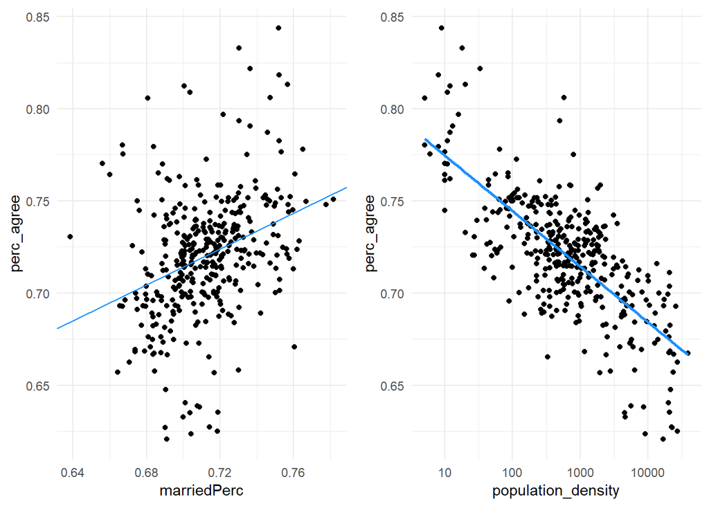

```r
library(gridExtra)

grid.arrange(plt1, plt2, ncol=2)
```

# Q4 Challenge: The median of grouped data

- Calculating age median of grouped data
- Reference: https://www.themathdoctors.org/finding-the-median-of-grouped-data/
- Solve it with dplyr pkgs
- If you can’t answer the question correctly, keep your code (even wrong) to get partial scores.

## **Q4 Ans: glimpse()**

```r
# glimpse(YOUR_DATA_FRAME_NAME)
age_town_tidy <- age_town %>%
  gather(key = "key", "value", -site_id) %>%
  mutate(key = str_replace(key, "15down", "0_14")) %>%
  mutate(key = str_replace(key, "100up", "100_105")) %>%
  mutate(key = str_replace(key, "single_age", "single")) %>%
  separate(key, c("married", "ageLower", "ageUpper", "gender")) %>%
  mutate(ageLower = as.numeric(ageLower),
         ageUpper = as.numeric(ageUpper),
         value = as.numeric(value))

glimpse(age_town_tidy)
```

```
## Observations: 55,936
## Variables: 6
## $ site_id  <chr> "宜蘭縣三星鄉", "宜蘭縣大同鄉", "宜蘭縣五結鄉", "宜蘭縣冬山鄉", "宜蘭縣壯圍鄉", "宜蘭...
## $ married  <chr> "single", "single", "single", "single", "single", "si...
## $ ageLower <dbl> 0, 0, 0, 0, 0, 0, 0, 0, 0, 0, 0, 0, 0, 0, 0, 0, 0, 0,...
## $ ageUpper <dbl> 14, 14, 14, 14, 14, 14, 14, 14, 14, 14, 14, 14, 14, 1...
## $ gender   <chr> "f", "f", "f", "f", "f", "f", "f", "f", "f", "f", "f"...
## $ value    <dbl> 772, 537, 1661, 2839, 1006, 6397, 578, 1441, 1455, 17...
```

```r
age_town_group <- age_town_tidy %>%
  group_by(site_id, ageLower) %>%
  summarise(value = sum(value))

# 找出中位數所在區間
index <- function(val) {
  sum = 0
  for (i in 1:length(val)) {
    sum = sum + val[i]
    if (sum >= sum(val)/2) {
      return (i)
      break
    }
  }
}

# 找出 median_group 必要參數並計算
group_median <- function(val, w = 5) {
  ind = index(val)
  L = df$ageLower[ind]
  B = sum(df$value[1:(ind-1)])
  n = sum(val)
  G = df$value[ind]

  median = L + ((n/2) - B)/G * w
  return(median)
}

# 對每個行政區套用 median_group
median <- vector()

for (site in age_town$site_id) {
  df <- filter(age_town_group, site_id == site)
  val <- df$value
  tmp <- group_median(val)
  median <- c(median, tmp)
}

result.df = data.frame(site_id = age_town$site_id, median = median)
result.df
```

```
##            site_id   median
## 1     宜蘭縣三星鄉 47.05568
## 2     宜蘭縣大同鄉 37.29541
## 3     宜蘭縣五結鄉 43.63057
## 4     宜蘭縣冬山鄉 42.76025
## 5     宜蘭縣壯圍鄉 44.35244
## 6     宜蘭縣宜蘭市 40.98803
## 7     宜蘭縣南澳鄉 35.41318
## 8     宜蘭縣員山鄉 43.69676
## 9     宜蘭縣頭城鎮 43.81682
## 10    宜蘭縣礁溪鄉 43.83521
## 11    宜蘭縣羅東鎮 40.09263
## 12    宜蘭縣蘇澳鎮 44.90566
## 13    花蓮縣玉里鎮 46.45936
## 14    花蓮縣光復鄉 49.09473
```

[output cut: 354 more lines]